> 14 Sep 2017 » statistics

수식이 깨질 경우 새로고침을 눌러주세요.

# 가설과 검정 ③

## One-Tailed Test(단측 검정) vs Two-Tailed Test(양측 검정)

### One-Tailed Test(단측 검정)

> 부호가 결정되어 있는 경우 $$H_0\;:\; \mu \leq 0\;:\;\; \mu가\; 양수이면서\; 희귀한\; 검정통계량\; 값이\; 나오는\; 경우에만\; 기각 $$

$$\alpha = 0.05\;인\; 경우 \;\; critical\; value는\; \text{CDF}(1-\alpha) = \text{CDF}(0.95) $$

> $$H_0\;:\; \mu \geq 0\;:\;\; \mu가\; 음수이면서\; 희귀한\; 검정통계량\; 값이\; 나오는\; 경우에만\; 기각 $$

$$\alpha = 0.05\;인\; 경우 \;\; critical\; value는\; \text{CDF}(\alpha) = \text{CDF}(0.05) $$

### Two-Tailed Test(양측 검정)

$$ H_0\;:\;\; \mu = 0\;:\;\; 부호와\; 상관없이\; 크기가\; 더\; 희귀한\; 검정통계량\; 값이\; 나오는\; 경우\; 기각 $$$$\alpha = 0.05\;인\; 경우 \;\; critical\; value는\; \text{CDF}(\alpha/2) = \text{CDF}(0.025)\; 와 \;\text{CDF}(1-\alpha/2) = \text{CDF}(0.975) $$

```python
# -*- coding: utf-8 -*-

import seaborn as sns
import pandas as pd
import scipy as sp
import matplotlib as mpl
import matplotlib.pylab as plt
import numpy as np
%matplotlib inline
from matplotlib.patches import Polygon


x = np.linspace(-5, 5, 100)
y = sp.stats.norm.pdf(x)

def plot_tailed(f, subplot, alpha, title=None):
    ax = f.add_subplot(subplot)
    ax.plot(x, y, linewidth=2)
    plt.hold(True)

    # critical point
    cr1 = sp.stats.norm.ppf(alpha)

    ## np.sign(x) -> -1, 0 으로 출력(x < 0 → -1, 나머지 경우는 0)
    cr2 = cr1 + np.sign(cr1) * 10

    ix = np.linspace(cr1, cr2, 100)
    iy = sp.stats.norm.pdf(ix)

    verts = [(cr1, 0)] + list(zip(ix, iy)) + [(cr2, 0)]
    poly = Polygon(verts)
    ax.add_patch(poly)
    plt.xlim(-5, 5)
    if title is not None:
        plt.title(title)
```

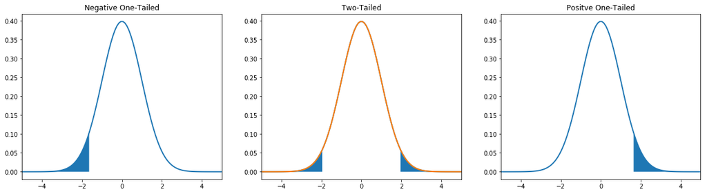

```python
alpha = 0.05
f = plt.figure(figsize=(20, 5))
plot_tailed(f, 131, alpha, "Negative One-Tailed")
plot_tailed(f, 133, 1 - alpha, "Positve One-Tailed")
plot_tailed(f, 132, alpha/2)
plot_tailed(f, 132, 1 - alpha/2, "Two-Tailed")
```

### 자주 쓰이는 검정 유형

> 이산 분포 파라미터 테스트
> - Bernoilli 분포의 파라미터 값이 theha인가 아닌가
>   - Binomial Test
> - Categorical 분포의 파라미터 값이 theta vector인가 아닌가
>   - Chi-Square Test

> 정규 분포 파라미터 테스트
> - 정규 분포의 mean 값이 0인가 아닌가
>   - One-sample z-test (분산값을 아는 경우)
>   - One-sample t-test (분산값을 모르는 경우)
> - 두 독립 정규 분포의 mean 값이 같은가 다른가
>   - Independent-Two-sample t-test
> - 두 Paired 정규 분포의 mean 값이 같은가 다른가
>   - Paired-Two-sample t-test
> - 두 정규 분포의 variance 값이 같은가 다른가
>   - Equal-Variance test

> 분포 확인 테스트
> - 분포가 정규 분포인가 아닌가
>   - Normality test
> - 두 분포가 같은 분포인가 아닌가 ← 기준이 되는 분포를 하나를 두고(대조군)
>   - Kolmogorov Smirnov test

## 기초적인 검정을 실습해보자.

### 이항 검정 (Binomial test)

> 이항 검정은 이항 분포를 이용하여 Bernoulli 분포 모수 theta에 대한 가설을 조사하는 검정 방법이다.
> - SciPy stats 서브패키지의 `binom_test`를 사용한다.
> - 디폴트 귀무 가설은 theta = 0.5
> - scipy.stats.binom_test
>   - http://docs.scipy.org/doc/scipy/reference/generated/scipy.stats.binom_test.html

$$ ex \;1)\; 데이터\; 갯수\; N=10,\; 실제\; 모수\; \theta = 0.5인\; 경우,\; 이항\; 검정을\; 해보자. $$

```python
N = 10
theta = 0.5
np.random.seed(0)
x = sp.stats.bernoulli(theta).rvs(N)
n = np.count_nonzero(x)
n
```

```
7
```

```python
# N번 시행 중 n번 성공할 확률
sp.stats.binom_test(n, N)
```

```
0.34374999999999989
```

#### 유의 확률(p-value) = 34%로 높으므로 다음 귀무 가설을 기각할 수 없다.

$$ H_0 : \theta = 0.5 $$

$$ ex \;2)\; 데이터\; 갯수\; N=100,\; 실제\; 모수\; \theta = 0.5인\; 경우,\; 이항\; 검정을\; 해보자. $$

```python
N = 100
theta = 0.5
np.random.seed(0)
x = sp.stats.bernoulli(theta).rvs(N)
n = np.count_nonzero(x)
n
```

```
49
```

```python
sp.stats.binom_test(n, N)
```

```
0.92041076261282062
```

#### 유의 확률(p-value) = 92%로 높으므로 다음 귀무 가설을 기각할 수 없다.

$$ H_0 : \theta = 0.5 $$

$$ ex \;3)\; 데이터\; 갯수\; N=100,\; 실제\; 모수\; \theta = 0.35인\; 경우,\; 이항\; 검정을\; 해보자. $$

```python
N = 100
theta = 0.35
np.random.seed(0)
x = sp.stats.bernoulli(theta).rvs(N)
n = np.count_nonzero(x)
n
```

```
31
```

```python
sp.stats.binom_test(n, N)
```

```
0.00018314322488235352
```

#### 유의 확률(p-value)이 0.018%로 낮으므로 다음 귀무 가설을 기각한다.

$$ H_0 : 기각 → \theta \neq 0.5 $$

### 카이 제곱 검정 (Chi-square test)

> 카이 제곱 검정은 goodness of fit 검정이라고도 부른다.

> Multinoulli 시도시 성공한 횟수로 파라미터 theta 벡터가 정해진 값을 만족하는지 검사한다. $$ 카테고리\; 분포의\; 모수\; \theta=(\theta_1, \ldots, \theta_K)에\; 대한\; 가설을\; 조사하는\; 검정\; 방법이다. $$

> SciPy stats 서브패키지의 `chisquare` 명령을 사용한다.
> - 디폴트 귀무 가설은 $\theta = \left(\frac{1}{K}, \ldots, \frac{1}{K} \right)$이다.
> - [scipy.stats.chisquare](http://docs.scipy.org/doc/scipy/reference/generated/scipy.stats.chisquare.html)

$$ ex 1)\;\;데이터\; 개수\; N=10,\; 실제\; 모수\; \theta\;=\;(0.25,\; 0.25,\; 0.25,\; 0.25)인\; 경우\; 카이\; 제곱\; 검정을\; 해보자. $$

```python
N = 10
K = 4
theta = np.ones(K)/K
np.random.seed(0)

# k개의 카테고리에서 p의 확률로, 이를 10번 수행해라.
x = np.random.choice(K, N, p=theta)
n = np.bincount(x, minlength=K)
n
```

```
array([0, 3, 5, 2])
```

```python
# 카테고리로 나눠진 어레이를 인풋으로 넣어준다.
sp.stats.chisquare(n)
```

```
Power_divergenceResult(statistic=5.1999999999999993, pvalue=0.157724450396663)
```

#### 유의 확률(p-value)이 15.7%로 높으므로 귀무 가설을 기각할 수 없다.

$$ 따라서\; H_0 : \theta \;=\; (0.25,\; 0.25,\; 0.25,\; 0.25)이다. $$

```python
N = 100
K = 4
theta = np.array([0.35, 0.30, 0.20, 0.15])
np.random.seed(0)

# k개의 카테고리에서 p의 확률로, 이를 10번 수행해라.
x = np.random.choice(K, N, p=theta)
n = np.bincount(x, minlength=K)
n
```

```
array([37, 32, 20, 11])
```

```python
sp.stats.chisquare(n)
```

```
Power_divergenceResult(statistic=16.559999999999999, pvalue=0.00087034719789121269)
```

#### 유의 확률(p-value)이 0.087%이므로 귀무 가설을 기각할 수 있다.

$$ 따라서\;H_0 : 기각 → \;\theta \neq (0.25,\; 0.25,\; 0.25,\; 0.25)이다. $$

### 단일 표본 z-검정 (One-sample z-test)

> 단일 표본 z-검정은 모분산의 값을 정확히 알고 있는 정규 분포의 표본에 대해 기대값을 조사하는 검정 방법이다.
> - 단, 실제로 이런 경우는 없어 사용할 일이 없다.

> 단일 표본 z-검정의 경우에는 SciPy에 별도의 함수가 준비되어 있지 않으므로 `norm` 명령의 `cdf` 메서드를 사용하여 직접 구현해야 한다.
> - [scipy.stats.norm](http://docs.scipy.org/doc/scipy/reference/generated/scipy.stats.norm.html)

$$ ex 1)\;\;데이터\; 개수\; N=10,\; 실제\; 모수\; \mu = 0인\; 경우\; 단일\; 표본\; z검정을\; 해보자. $$

```python
N = 10
mu = 0
np.random.seed(0)
x = sp.stats.norm(mu).rvs(N)
x
```

```
array([ 1.76405235,  0.40015721,  0.97873798,  2.2408932 ,  1.86755799,
       -0.97727788,  0.95008842, -0.15135721, -0.10321885,  0.4105985 ])
```

```python
def z_test_1_sampling(x, sigma_2=1, mu=0):
    z = (x.mean() - mu)/ np.sqrt(sigma_2 / len(x))
    p_value = 2 * sp.stats.norm().sf(np.abs(z))
    return (z, p_value)
```

```python
z_test_1_sampling(x)
```

```
(2.3338341854824276, 0.019604406021683538)
```

#### 유의 확률(p-value) = 0.0196 이므로 유의 수준 = 0.05 이라면 귀무 가설을 기각할 수 있다.

$$H_0 : 기각 → \mu \neq 0$$

> 이 경우는 검정 결과가 오류인 예라고 볼 수 있다.
> - 검정 결과가 오류로 나온 이유는 데이터 수가 10개로 부족하기 때문이다.
> - 제 1종 오류(Type 1 Error) : 귀무 가설이 참임에도 기각하는 경우

$$ ex 2)\;\;데이터\; 개수\; N=100,\; 실제\; 모수\; \mu = 0인\; 경우\; 단일\; 표본\; z검정을\; 해보자. $$

```python
N = 100
mu = 0
np.random.seed(0)
x = sp.stats.norm(mu).rvs(N)
```

```python
z_test_1_sampling(x)
```

```
(0.59808015534484993, 0.54978645086241684)
```

#### 유의 확률(p-value) = 0.5497 이므로 귀무 가설을 기각할 수 없다.

$$ H_0 : \mu = 0 $$

### 단일 표본 t-검정 (One-sample t-test)

> 정규 분포의 표본에 대해 기대값을 조사하는 검정 방법이다.

> scipy의 stats 서브 패키지의 `ttest_1samp`을 사용한다.
> - `ttest_1samp` 명령의 경우에는 디폴트 모수가 없으므로 `popmean` 인수를 사용하여 직접 지정해야 한다.
> - [scipy.stats.ttest_1samp](http://docs.scipy.org/doc/scipy/reference/generated/scipy.stats.ttest_1samp.html)

$$ ex 1)\;\;데이터\; 개수\; N=10,\; 실제\; 모수\; \mu = 0인\; 경우\; 단일\; 표본\; t-test를\; 해보자. $$

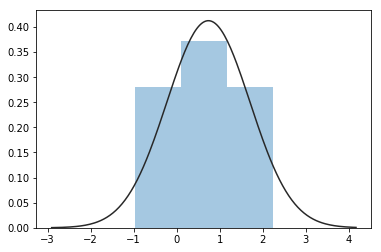

```python
N = 10
mu = 0
np.random.seed(0)
x = sp.stats.norm(mu).rvs(N)
sns.distplot(x, kde=False, fit=sp.stats.norm)
plt.show()
```

```python
sp.stats.ttest_1samp(x, popmean=0)
```

```
Ttest_1sampResult(statistic=2.2894396723896699, pvalue=0.047818464908570578)
```

$$H_0 : 기각 → \mu \neq 0 $$

> 마찬가지로 제 1종 오류(귀무가설이 참일 때 기각할 오류, 샘플수가 적기 때문이다.)

$$ ex 2)\;\;데이터\; 개수\; N=100,\; 실제\; 모수\; \mu = 0인\; 경우\; 단일\; 표본\; t-test를\; 해보자. $$

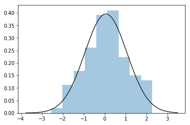

```python
N = 100
mu = 0
np.random.seed(0)
x = sp.stats.norm(mu).rvs(N)
sns.distplot(x, kde=False, fit=sp.stats.norm)
plt.show()
```

```python
sp.stats.ttest_1samp(x, popmean=0)
```

```
Ttest_1sampResult(statistic=0.59042834028516977, pvalue=0.55624891586946745)
```

#### p-value = 0.5562 이므로 유의 수준 = 0.05일 때 귀무가설을 기각할 수 없다.

$$H_0 : \mu = 0 $$

### 독립 표본 t-검정 (Independent-two-sample t-test)

> Independent-two-sample t-test는 간단하게 two sample t-test라고도 한다.
> - 두 개의 독립적인 정규 분포에서 나온 두 개의 데이터 셋을 사용하여 두 정규 분포의 기대값이 동일한지를 검사한다.
> - scipy stats 서브패키지의 `ttest_ind`를 사용한다.
> - 독립 표본 t-검정은 두 정규 분포의 분산값이 같은 경우와 같지 않은 경우에 사용하는 검정 통계량이 다르다.
>   - **`equal_var` 인수를 사용하여 이를 지정해 주어야 한다.**
> - [scipy.stats.ttest_ind](http://docs.scipy.org/doc/scipy/reference/generated/scipy.stats.ttest_ind.html)

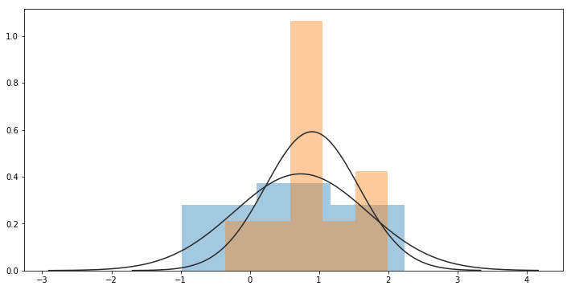

```python
N_1 = 10; mu_1 = 0; sigma_1 = 1
N_2 = 10; mu_2 = 0.5; sigma_2 = 1
np.random.seed(0)
x1 = sp.stats.norm(mu_1, sigma_1).rvs(N_1)
x2 = sp.stats.norm(mu_2, sigma_2).rvs(N_2)

plt.figure(figsize=(12,6))
sns.distplot(x1, kde=False, fit=sp.stats.norm)
sns.distplot(x2, kde=False, fit=sp.stats.norm)
plt.show()
```

```python
sp.stats.ttest_ind(x1, x2, equal_var=True)
```

```
Ttest_indResult(statistic=-0.41399685269886549, pvalue=0.68376768941164268)
```

#### p-value = 0.6837 이므로 유의 수준 = 0.05일 때 귀무가설을 기각할 수 없다.

$$H_0 : \mu_1 = \mu_2 $$

> 이 경우는 검정 결과가 오류다. 제 2종 오류(Type 2 Error) 귀무 가설이 거짓임에도 참으로 나온 경우
> - 데이터 수를 더 늘려야 한다.

### 샘플 수를 더 늘려서 다시 해보면

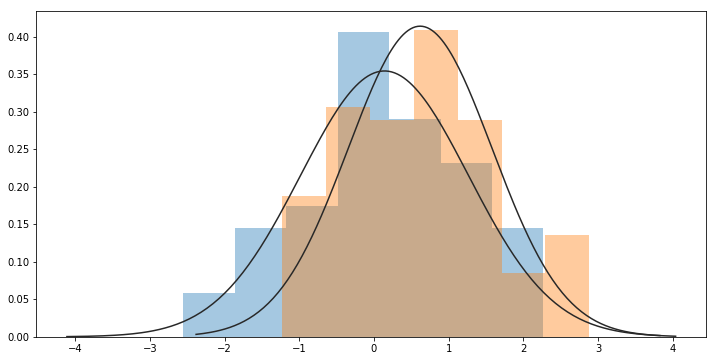

```python
N_1 = 50; mu_1 = 0; sigma_1 = 1
N_2 = 100; mu_2 = 0.5; sigma_2 = 1
np.random.seed(0)
x1 = sp.stats.norm(mu_1, sigma_1).rvs(N_1)
x2 = sp.stats.norm(mu_2, sigma_2).rvs(N_2)

plt.figure(figsize=(12,6))
sns.distplot(x1, kde=False, fit=sp.stats.norm)
sns.distplot(x2, kde=False, fit=sp.stats.norm)
plt.show()
```

```python
sp.stats.ttest_ind(x1, x2, equal_var=True)
```

```
Ttest_indResult(statistic=-2.6826951236616963, pvalue=0.0081339709157226582)
```

#### p-value = 0.0081 이므로 유의 수준 = 0.05일 때 귀무가설을 기각할 수 있다.

$$H_0 : 기각 → \mu_1 \neq \mu_2 $$

### 대응 표본 t-검정 (Paired-two-sample t-test)

> 대응 표본 t-검정은 독립 표본 t-검정을 두 집단의 샘플이 1대1 대응하는 경우에 대해 수정한 것이다.

> 즉, 독립 표본 t-검정과 마찬가지로 두 정규 분포의 기대값이 같은 지 확인하기 위한 검정
> - 예를 들어 어떤 반의 학생들이 특강을 수강하기 전과 수강한 이후에 각각 시험을 본 시험 점수의 경우에는 같은 학생의 두 점수는 대응할 수 있다.
> - 이 대응 정보를 알고 있다면 보통의 독립 표본 t-검정에서 발생할 수 있는 샘플 간의 차이의 영향을 없앨 수 있기 때문에 특강 수강의 영향을 보다 정확하게 추정할 수 있다.
> - [scipy.stats.ttest_rel](http://docs.scipy.org/doc/scipy/reference/generated/scipy.stats.ttest_rel.html)

$$ ex)\;\;데이터\; 개수\; N = 5,\; 두\; 정규\; 분포의\; 기대값이\; \mu_1 = 0,\; \mu_2 = 0.5로\; 달라진 경우,\; Paired-two-sample \;t-test를\; 해보자. $$

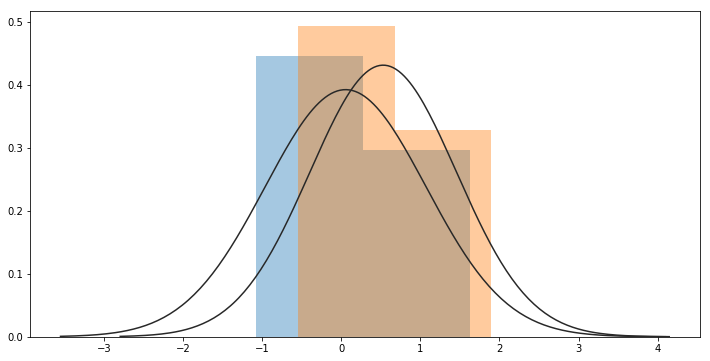

```python
N = 5
mu_1 = 0
mu_2 = 0.5

np.random.seed(1)
x1 = sp.stats.norm(mu_1).rvs(N)
# 표준편차 = 0.1 추가로 설정
x2 = x1 + sp.stats.norm(mu_2, 0.1).rvs(N)

plt.figure(figsize=(12,6))
sns.distplot(x1, kde=False, fit=sp.stats.norm)
sns.distplot(x2, kde=False, fit=sp.stats.norm)
plt.show()
```

```python
sp.stats.ttest_rel(x1, x2)
```

```
Ttest_relResult(statistic=-7.1723380661732756, pvalue=0.0020008849290622677)
```

#### p-value = 0.002 이므로 유의 수준 = 0.05일 때 귀무가설을 기각할 수 있다.

$$H_0 : 기각 → \mu_1 \neq \mu_2 $$

> 5 개의 데이터만으로도 두 평균이 다르다는 것을 알아낼 수 있다.

### 카이 제곱 분산 검정 (Chi-Square Test for the Variance)

> 지금까지는 정규 분포의 기대값을 비교하는 검정을 살펴보았다. 이제는 정규 분포의 분산에 대해 살펴보자.

> 카이 제곱 분산 검정(Chi-Square Test for the Variance)은 **정규 분포의 샘플 분산값은 정규화하면 카이 제곱 분포를 따른다는 점을 이용하는 검정 방법**이다.

> scipy는 카이 제곱 분산 검정에 대한 명령이 없으므로 `chi2` 클래스를 사용하여 직접 구현해야 한다.

```python
def chi2var_test(x, sigma2=1):
    v = x.var(ddof=1)
    t = (len(x) - 1)*v/sigma2
    p_value = sp.stats.chi2(df=len(x)-1).sf(np.abs(t))
    return (t, p_value)
```

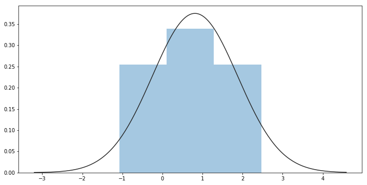

```
1.0637871321863899
```

```python
N = 10
mu_0 = 0
sigma_0 = 1.1

np.random.seed(0)
x = sp.stats.norm(mu_0, sigma_0).rvs(N)

plt.figure(figsize=(12,6))
sns.distplot(x, kde=False, fit=sp.stats.norm)
plt.show()
x.std()
```

```python
chi2var_test(x)
```

```
(11.316430626053437, 0.25464123584764542)
```

### 등분산 검정 (Equal-variance test)

> 등분산 검정은 두 정규 분포로부터 생성된 두 개의 데이터 집합으로부터 두 정규 분포의 분산 모수가 같은지 확인하기 위한 검정이다.
> - 가장 기본적인 방법은 F분포를 사용하는 것이지만 실무에서는 이보다 더 성능이 좋은 bartlett, fligner, levene 방법을 주로 사용한다.
> - scipy의 stats 서브패키지는 이를 위한 `bartlett`, `fligner`, `levene` 명령을 제공한다.
> - [scipy.stats.bartlett](http://docs.scipy.org/doc/scipy/reference/generated/scipy.stats.bartlett.html)
> - [scipy.stats.fligner](http://docs.scipy.org/doc/scipy/reference/generated/scipy.stats.fligner.html)
> - [scipy.stats.levene](http://docs.scipy.org/doc/scipy/reference/generated/scipy.stats.levene.html)

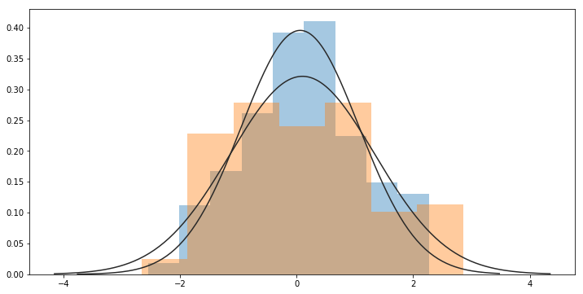

```
(1.0078822447165796, 1.2416003969261071)
```

```python
N1 = 100
N2 = 100
sigma_1 = 1
sigma_2 = 1.2

np.random.seed(0)
x1 = sp.stats.norm(0, sigma_1).rvs(N1)
x2 = sp.stats.norm(0, sigma_2).rvs(N2)

plt.figure(figsize=(12,6))
sns.distplot(x1, kde=False, fit=sp.stats.norm)
sns.distplot(x2, kde=False, fit=sp.stats.norm)
plt.show()
x1.std(), x2.std()
```

```python
sp.stats.bartlett(x1, x2)
```

```
BartlettResult(statistic=4.2534738372322662, pvalue=0.039170128783651344)
```

```python
sp.stats.fligner(x1, x2)
```

```
FlignerResult(statistic=7.2248419904094572, pvalue=0.0071901501067483673)
```

```python
sp.stats.levene(x1, x2)
```

```
LeveneResult(statistic=7.6807089476794372, pvalue=0.0061135154970207925)
```

|  | bartlett | fligner | levene |
| --- | --- | --- | --- |
| p-value | 0.03917 | 0.0071 | 0.0061 |

#### 위에서 보듯이 세 가지의 등분산 검정 결과 모두 귀무 가설을 기각할 수 있다.

> $$H_0 : 기각 → \sigma_1 \neq \sigma_2 $$

### 정규성 검정

> 회귀 분석 등에서는 확률 분포가 가우시안 정규 분포를 따르는지 아닌지를 확인하는 것이 중요하다.

> 이러한 검정을 정규성 검정(Normality Test)이라고 한다.

### statsmodels에서 제공하는 정규성 검정 명령어

- Omnibus Normality test
  - [`statsmodels.stats.stattools.omni_normtest`](http://statsmodels.sourceforge.net/devel/generated/statsmodels.stats.stattools.omni_normtest.html)
- Jarque–Bera test
  - [`statsmodels.stats.stattools.jarque_bera`](http://statsmodels.sourceforge.net/devel/generated/statsmodels.stats.stattools.jarque_bera.html)
- Kolmogorov-Smirnov test
  - [`statsmodels.stats.diagnostic.kstest_normal`](http://statsmodels.sourceforge.net/devel/generated/statsmodels.stats.diagnostic.kstest_normal.html)
- Lilliefors test
  - [`statsmodels.stats.diagnostic.lillifors`](http://statsmodels.sourceforge.net/devel/generated/statsmodels.stats.diagnostic.lillifors.html)

### scipy 에서 제공하는 정규성 검정 명령어

- Kolmogorov-Smirnov test
  - [`scipy.stats.ks_2samp`](http://docs.scipy.org/doc/scipy/reference/generated/scipy.stats.ks_2samp.html)
- Shapiro–Wilk test
  - [`scipy.stats.shapiro`](http://docs.scipy.org/doc/scipy/reference/generated/scipy.stats.shapiro.html)
- Anderson–Darling test
  - [`scipy.stats.anderson`](http://docs.scipy.org/doc/scipy/reference/generated/scipy.stats.anderson.html)
- D'Agostino's K-squared test
  - [`scipy.stats.mstats.normaltest`](http://docs.scipy.org/doc/scipy/reference/generated/scipy.stats.mstats.normaltest.html)

### 이 중에서 Kolmogorov-Smirnov 검정은 정규 분포에 국한되지 않고 두 샘플이 같은 분포를 따르는지 확인할 수 있는 방법이다.

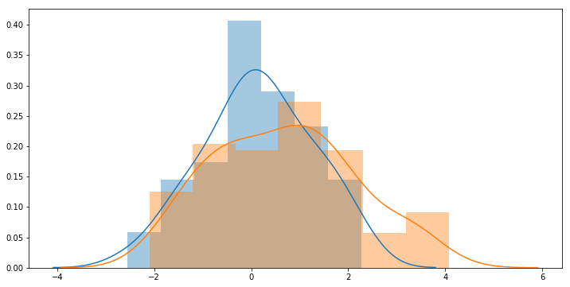

```python
np.random.seed(0)
N1 = 50
N2 = 100

x1 = sp.stats.norm(0, 1).rvs(N1)
x2 = sp.stats.norm(0.5, 1.5).rvs(N2)

plt.figure(figsize=(12,6))
sns.distplot(x1)
sns.distplot(x2)
plt.show()
```

```python
sp.stats.ks_2samp(x1, x2)
```

```
Ks_2sampResult(statistic=0.23000000000000004, pvalue=0.049516112814422863)
```

#### p-value = 0.04951 이므로 유의 수준 = 0.05일 때 귀무가설을 기각할 수 있다.

$$H_0 : 기각 → X_1,\; X_2가\; 따르는\; 분포는\; 서로\; 다른 \;분포라고\; 볼\; 수\; 있다. $$

> Share this on → [Tweet](https://twitter.com/share)

#### Related Posts

- [모수 추정 ③ (베이지안 모수 추정 MAP)](http://localhost:4000/statistics/2017/09/18/probability/) (Categories: statistics)
- [모수 추정 ② (MLE 계산)](http://localhost:4000/statistics/2017/09/17/probability/) (Categories: statistics)
- [모수 추정 ① (MM, MLE)](http://localhost:4000/statistics/2017/09/15/probability/) (Categories: statistics)
- [가설과 검정 ②](http://localhost:4000/statistics/2017/09/13/probability_1/) (Categories: statistics)
- [가설과 검정 ①](http://localhost:4000/statistics/2017/09/13/probability/) (Categories: statistics)
- [다변량 가우시안 정규분포](http://localhost:4000/probability/statistics/2017/09/11/probability_2/) (Categories: probability, statistics)

> « 가설과 검정 ② Python basic (객체지향 프로그래밍 ④) »